# Can Money Buy Happiness?

PSY6422 Project

220225410

2023-05-16

[figure not shown]

# **Background**

The World Happiness Report has reviewed the state of happiness across the world since 2011. The report makes use of life evaluations from Gallup World Poll data which provide the basis of the happiness rankings. Life evaluation questions are assessed using the Cantril ladder, which asks respondents to think of a ladder where 10 is the best possible life, and 0 is the worst possible life. Six variables are used to explain the variation in happiness levels across the countries. These include GDP per capita, social support, life expectancy, freedom, generosity, and corruption.

## **What Makes Us Happy?**

The common expression ‘money can’t buy happiness’ has been around for centuries and is a widely accepted notion, but is this true? What if you are living paycheck to paycheck? In this case, winning the lottery would relieve stress and inevitably increase happiness. So, does this imply that this statement is wrong?

This project aims to visualise global happiness ratings, as well as average national income per capita, to assess if there is a relationship between the two variables.

## **Research Questions**

Aims of this data visualisation:

1. Which countries are the happiest and the least happy?
2. How has happiness changed over the last 10 years?
3. Which countries are the richest and the poorest based on average national income per capita?
4. Is there a relationship between average income and overall happiness?

## **Data Origins**

Happiness data sourced from [World Happiness Report](https://worldhappiness.report/ed/2021/) (Accessed on: 01-03-2023)

Average national income sourced from [The United Nations Development Programme](https://hdr.undp.org/data-center/human-development-index#/indicies/HDI) (Accessed on: 01-03-2023)

Average income data was sourced from the human development index. Gross National Income (GNI) per capita is one measurement of the human development index, a summary measurement of three key dimensions of human development, including healthy life, education and standard of living.

## **Data Preparation**

Before loading the data, the libraries are loaded and fonts are imported.

### Loading Happiness Data

```r
#------------------------------LOADING THE DATA----------------------------------
#Loading happiness data from data folder
Happiness <- read_xls(here("Data", "WorldHappinessReport.xls"))

#Show first few rows of raw data
head(Happiness)
```

```
## # A tibble: 6 × 12
##   Countr…¹  year Life …² Log G…³ Socia…⁴ Healt…⁵ Freed…⁶ Gener…⁷ Perce…⁸ Posit…⁹
##   <chr>    <dbl>   <dbl>   <dbl>   <dbl>   <dbl>   <dbl>   <dbl>   <dbl>   <dbl>
## 1 Afghani…  2008    3.72    7.30   0.451    50.5   0.718  0.173    0.882   0.414
## 2 Afghani…  2009    4.40    7.47   0.552    50.8   0.679  0.195    0.850   0.481
## 3 Afghani…  2010    4.76    7.58   0.539    51.1   0.600  0.126    0.707   0.517
## 4 Afghani…  2011    3.83    7.55   0.521    51.4   0.496  0.168    0.731   0.480
## 5 Afghani…  2012    3.78    7.64   0.521    51.7   0.531  0.241    0.776   0.614
## 6 Afghani…  2013    3.57    7.66   0.484    52     0.578  0.0663   0.823   0.547
## # … with 2 more variables: `Negative affect` <dbl>,
## #   `Confidence in national government` <dbl>, and abbreviated variable names
## #   ¹`Country name`, ²`Life Ladder`, ³`Log GDP per capita`, ⁴`Social support`,
## #   ⁵`Healthy life expectancy at birth`, ⁶`Freedom to make life choices`,
## #   ⁷Generosity, ⁸`Perceptions of corruption`, ⁹`Positive affect`
```

### Data Wrangling

The data set includes several variables contributing to the overall measurement of well-being, but for this visualisation, the main focus will be the general life ladder score and the relationship between average national income per capita provided by another data set. Therefore, the variables selected are country, year and life ladder.

The data was filtered to 2011-2021 to focus on 10 years of happiness ratings. This filtered out many missing data points as more countries joined the World Happiness Report in subsequent years.

```r
#-------------------------DATA WRANGLING-----------------------------------------
#Creating data frame
HappinessReport = as.data.frame(Happiness)

#Selecting and renaming the variables
HappinessReport <- Happiness %>%
                   select('Country name', year, 'Life Ladder') %>% #Select old variable names
                   rename(Country = 'Country name', Year = year, #Apply new names
                          Happiness_Score = 'Life Ladder')

#Filtering years to 2011-2021
HappinessReport <- HappinessReport[HappinessReport$Year >= "2011" &
                                     HappinessReport$Year <= "2021",]

#Show first few rows of processed data
head(HappinessReport)
```

```
## # A tibble: 6 × 3
##   Country      Year Happiness_Score
##   <chr>       <dbl>           <dbl>
## 1 Afghanistan  2011            3.83
## 2 Afghanistan  2012            3.78
## 3 Afghanistan  2013            3.57
## 4 Afghanistan  2014            3.13
## 5 Afghanistan  2015            3.98
## 6 Afghanistan  2016            4.22
```

### Codebook

| Variable_ID | Type | Description |
| --- | --- | --- |
| Country | character | Country of the happiness rating |
| Year | numeric | Year that the happiness score was recorded |
| Happiness_Score | numeric | Happiness score based on the Cantril ladder scale, measuring well being as a continuum where 10 is the best possible life, and 0 is the worst possible life |

## **Visualisation 1: Happiest and Least Happy Countries on Average Between 2011-2021**

For the first visualisation, the average happiness score was calculated for each country to identify which countries are the happiest and the least happy between 2011-2021.

```r
#--------------------------SUMMARY STATISTICS------------------------------------
#Finding average happiness score of each country
Average <- HappinessReport %>%
              group_by(Country) %>% #Specify happiness score as column for summary statistics
              summarise_at(vars(Happiness_Score), #Specify summary statistics as computing mean
              list(Happiness_Score = mean))
```

### Creating a Bar Chart of The Top 10 Happiest Countries on Average

```r
#Select top 10 happiest countries on average
Top10 <- Average %>%
            arrange(desc(Happiness_Score)) %>% #Arrange happiness score in descending order
            slice(1:10) %>%  #Select the first 10 data points
            arrange(Happiness_Score) %>% #Rearranging score = highest plotted first
            mutate(Country = factor(Country, levels = Country)) #Mutate country column to display correct order

#Plot top 10 happiest countries
p_top10 <- ggplot(Top10, aes(Country, Happiness_Score, fill = Happiness_Score)) #Add mappings to ggplot

p_top10 <- p_top10 + #Add geom layer to ggplot
           geom_col() + #Plot x and y as a bar chart
           coord_flip() + #Making the bars horizontal
           scale_fill_gradient2(low = "#FFF9C4", high = "#FFEB3B", mid = "#FFF176",
           midpoint = median(Top10$Happiness_Score)) + #Fill the bars based on happiness score
           geom_text(aes(label = round(Happiness_Score, 3)),
                     nudge_y = -.55, color = "black") + #Add score on bar, adjust location
           labs(title = "Top 10 Happiest Countries on Average Between 2011-2021", #Add labels
           subtitle = "0 = Worst Possible Life, 10 = Best Possible Life",
           y = "Average Happiness Score",
           caption = "Source: World Happiness Report, Gallup World Poll") +
           theme_bw() + #Setting plot theme
           theme(text = element_text(family = "Arial"), #Change font
                 plot.title = element_text(face = "bold"), #Bold title
                 plot.title.position = "plot", #Move title
                 panel.border = element_blank(), #Remove background
                 legend.position="none") #Remove legend

#Saving the plot
ggsave(here("Figures", "Top 10 Happiest Countries.png"), plot = p_top10)
```

### Creating a Bar Chart of The Top 10 Least Happy Countries on Average

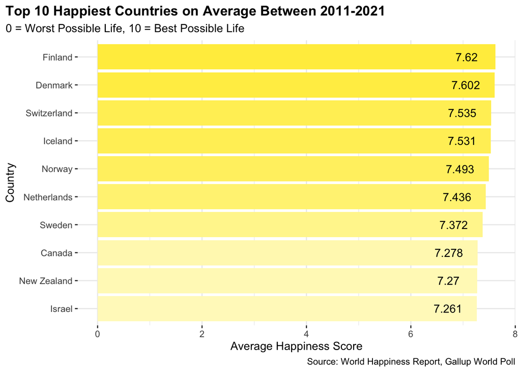

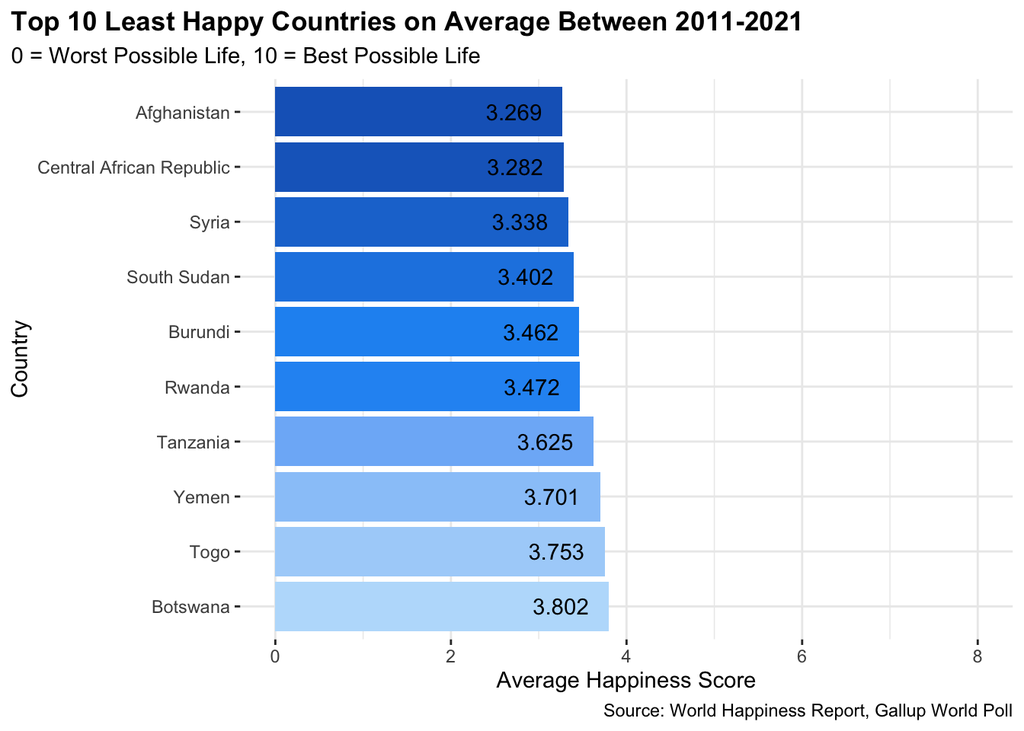

```r
#Finding top 10 least happy countries
Least10 <- Average %>%
              arrange(Happiness_Score) %>% #Arrange happiness score in ascending order
              slice(1:10) %>% #Select the first 10 data points
              arrange(desc(Happiness_Score)) %>% #Rearranging scores = plot lowest to highest
              mutate(Country = factor(Country, levels = Country)) #Mutate country column to display correct order

#Plotting top 10 least happy countries
p_least10 <- ggplot(Least10, aes(Country, Happiness_Score, fill = Happiness_Score)) #Add mappings to ggplot

p_least10 <- p_least10 +  #Add geom layer to ggplot
             geom_col() +  #Plot x and y as bar chart
             coord_flip() +  #Making the bars horizontal
             ylim(0, 8) +  #Set y axis scale to match top 10 happiest countries
             scale_fill_gradient2(low = "#0D47A1", high = "#BBDEFB", mid = "#2196F3",
             midpoint = median(Least10$Happiness_Score)) +  #Fill bars based on happiness score
             geom_text(aes(label = round(Happiness_Score, 3)),
                       nudge_y = -.55, color = "black") + #Add score on bar, adjust location
             labs(title = "Top 10 Least Happy Countries on Average Between 2011-2021", #Add labels
             subtitle = "0 = Worst Possible Life, 10 = Best Possible Life",
             y = "Average Happiness Score",
             caption = "Source: World Happiness Report, Gallup World Poll") +
             theme_bw() + #Set plot theme
             theme(text = element_text(family = "Arial"), #Change font
                   plot.title = element_text(face = "bold"), #Bold title
                   plot.title.position = "plot", #Move title
                   panel.border = element_blank(), #Remove background
                   legend.position="none") #Remove legend

#Saving the plot
ggsave(here("Figures", "Top 10 Least Happy Countries.png"), plot = p_least10)

#The following was included in the rMarkdown code block to plot each graph side by side
#{r, echo=FALSE, fig.show="hold", out.width="50%"}
```

**Aim 1 = Which countries are the happiest and the least happy?**  
This visualisation shows that 7 out of the top 10 happiest countries are located in Europe, whereas 7 out of the top 10 least happy countries are located in Africa, with roughly half the happiness scores of those located in Europe. This already sheds light on the causes of the difference in happiness scores. With Africa being the poorest continent in the world, this could imply a relationship between money and happiness, reinforcing the motivation for this data visualisation.

## **Visualisation 2: Choropleth Map of World Happiness 2011-2021**

The second visualisation focuses on how happiness ratings have changed over time during the 10 year period.

There were several missing data points for various countries, but the decision was made not to create averages for these missing points. It was likely that the data was unable to be collected either due to war or natural disaster etc. and therefore, creating an average of surrounding data points for the missing point would not be a true reflection of the happiness score for that year. Consequently, these points have been left blank and show up as grey on the map.

### Loading The World Map

```r
#---------------------------------PLOTTING WORLD MAP-----------------------------
#Loading world map
world_map <- map_data("world")

#Remove Antarctica
world_map <- subset(world_map, region != "Antarctica")

#Recoding country names to match data
HappinessReport$Country <- recode(HappinessReport$Country,
                                  'United States' = 'USA',
                                  'United Kingdom' = 'UK')
```

#### Plotting the choropleth map

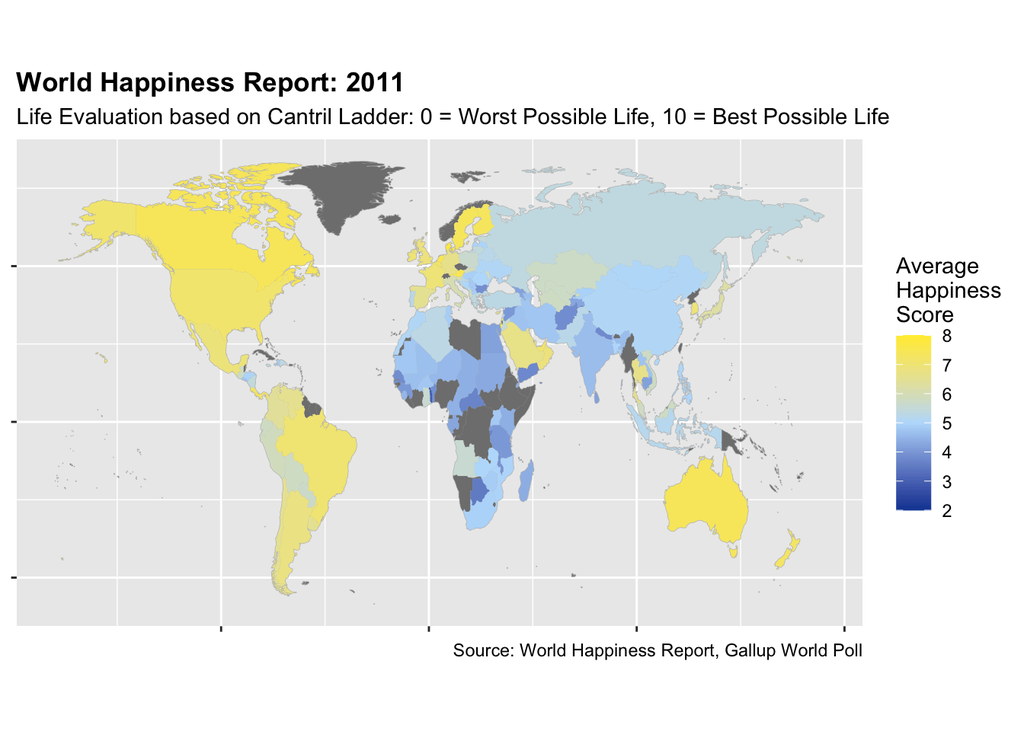

```r
#-------------------------PLOTTING CHOROPLETH MAP--------------------------------
#The following line of code was included in the rmarkdown code block to combine the plots into a GIF
#{r, animation.hook='gifski', interval=1, fig.align='center', out.width="110%"}

#Wrapping legend title for plotted map
name <- c("Average Happiness Score")
name <- str_wrap(name, width = 5)

#List containing each year to be used in the title of each map
Year <- list("2011", "2012", "2013", "2014", "2015", "2016", "2017", "2018", "2019", "2020", "2021")

#For loop to create choropleth map for each year
my_plots = list()
for(i in 1:11) {

  #Year index starting from 2011 and increasing to 2021
  Year1 = 2010 + i

  #Selecting specific data using the index
  HappinessYear <- filter(HappinessReport, Year == Year1)

  #Joining country in happiness data to region in world map data
  World_Map_Joined <- left_join(world_map, HappinessYear, by = c('region' = 'Country'))

  #Creating the choropleth plot
  p <- ggplot(World_Map_Joined, aes(long, lat)) + #Adding mappings to ggplot
       geom_map(dat = world_map, map = world_map, #Plotting countries on map
       aes(map_id = region), fill = "white", color = 'grey', linewidth = 0.25) + #Filling in the countries
       labs(title = sprintf("World Happiness Report: %s", Year[i]), #Adding labels
       subtitle = "Life Evaluation based on Cantril Ladder: 0 = Worst Possible Life, 10 = Best Possible Life",
       caption = "Source: World Happiness Report, Gallup World Poll") +
       theme(text = element_text(family = "Arial"), #Change font
             plot.title = element_text(face = "bold"), #Make title bold
             axis.title = element_blank(), #Removing x and y labels
             axis.text.x = element_blank(),
             axis.text.y = element_blank())

  #Plotting happiness scores onto the map
  p_out <- p + geom_map(map = World_Map_Joined, aes(map_id = region, fill = Happiness_Score),
           linewidth = 0.25) + #Plotting happiness score onto map
           scale_fill_gradient2(low = "#0D47A1", high = "#FFEB3B", #Filling countries based on happiness score
                                mid = "#BBDEFB", midpoint = 5,
                                name = name, limits = c(2, 8)) + #Assign pre made label for legend, set limits
           coord_fixed(1.5) #Fixing aspect ratio

  print(p_out)

  #Saving each plot
  ggsave(here("Figures", file=paste0("plot_", 2010 + i,".png")))
}
```

**Aim 2 = How has happiness changed over the last 10 years?**  
The use of the gradient colour scale ranging from blue (representing sadness) to yellow (representing happiness) shows the substantial variation in happiness ratings across the world. The choropleth map shows that North America, Oceania and Europe have hadnconsistently high happiness ratings over the last 10 years. However, the brightness of the yellow decreases throughout the years, suggesting overall happiness has decreased over this time period. In contrast, there is a lot of inconsistency in scores for countries located in Africa and Asia, made visible by the blue colours as well as the frequent changes in colour.

## **Visualisation 3: Top 10 Richest and Poorest Countries on Average in 2021**

Next, the average national income per capita data is loaded to visualise the relationship with happiness ratings.

For the purpose of this visualisation and in order to be able to answer the research questions, the average income data set was joined with the happiness report data for 2021, to ensure that only the countries with a happiness rating are plotted. This allows for the relationship between the two variables to be explored.

### Loading Average Income Data

```r
#---------------------------------LOADING AVERAGE INCOME DATA--------------------
#Loading the data
Average_Income <- read.csv(here("Data", "HumanDevelopmentReport.csv"))

#Showing first few rows of raw data
head(Average_Income)
```

```
##       Back Table.1..Human.Development.Index.and.its.components
## 1
## 2
## 3
## 4
## 5 HDI rank                                             Country
## 6
##                                X X.1                      X.2 X.3
## 1                                 NA
## 2                                 NA                     SDG3
## 3                                 NA
## 4 Human Development Index (HDI)   NA Life expectancy at birth
## 5                          Value  NA                  (years)
## 6                           2021  NA                     2021
##                           X.4 X.5                     X.6 X.7
## 1
## 2                      SDG4.3                      SDG4.4
## 3
## 4 Expected years of schooling     Mean years of schooling
## 5                     (years)                     (years)
## 6                        2021   a                    2021   a
##                                      X.8 X.9                               X.10
## 1
## 2                                 SDG8.5
## 3
## 4 Gross national income (GNI) per capita     GNI per capita rank minus HDI rank
## 5                           (2017 PPP $)
## 6                                   2021                                   2021
##   X.11     X.12 X.13 X.14 X.15 X.16 X.17 X.18 X.19 X.20 X.21 X.22 X.23 X.24
## 1                 NA   NA   NA   NA   NA   NA   NA   NA   NA   NA   NA   NA
## 2                 NA   NA   NA   NA   NA   NA   NA   NA   NA   NA   NA   NA
## 3                 NA   NA   NA   NA   NA   NA   NA   NA   NA   NA   NA   NA
## 4      HDI rank   NA   NA   NA   NA   NA   NA   NA   NA   NA   NA   NA   NA
## 5                 NA   NA   NA   NA   NA   NA   NA   NA   NA   NA   NA   NA
## 6    b     2020   NA   NA   NA   NA   NA   NA   NA   NA   NA   NA   NA   NA
```

### Data Wrangling

```r
#--------------------------------DATA WRANGLING----------------------------------
#Removing unwanted data
Average_Income <- Average_Income %>%
                  filter(!row_number() %in% c(1:7, 202:276)) %>% #Remove unwanted data
                  select(Table.1..Human.Development.Index.and.its.components, X.8) %>% #Select long variables
                  rename(Country = Table.1..Human.Development.Index.and.its.components,
                  Average.Income = X.8) %>% #Renaming long variables
                  mutate_all(na_if, "") %>% #Entering NA for missing data
                  na.omit() #Removing rows containing NA

#Remove comma in average income to make class numeric
Average_Income$Average.Income <- as.numeric(gsub(",", "", Average_Income$Average.Income))

#Selecting data from 2021 in happiness report
Happiness2021 <- HappinessReport %>%
                 filter(Year == "2021") %>% #Selecting year 2021
                 na.omit() #Remove any countries without a score for 2021

#Joining the happiness data in 2021 to average income data so only countries that also
#have a happiness rating are plotted
Joined_Data <- left_join(Happiness2021, Average_Income, by = "Country") %>% #Join both datasets by country
               select(Country, Happiness_Score, Average.Income) %>% #Select all columns
               na.omit() #Remove any countries with missing data

#Show first few rows of processed data
head(Joined_Data)
```

```
## # A tibble: 6 × 3
##   Country     Happiness_Score Average.Income
##   <chr>                 <dbl>          <dbl>
## 1 Afghanistan            2.44           1824
## 2 Albania                5.26          14131
## 3 Algeria                5.22          10800
## 4 Argentina              5.91          20925
## 5 Armenia                5.30          13158
## 6 Australia              7.11          49238
```

### Codebook

| Variable_ID | Type | Description |
| --- | --- | --- |
| Country | character | Country of the average income |
| Average.Income | numeric | Gross National Income (GNI) per capita, measured in American dollars ($). Each income has been corrected using purchasing power parity to adjust for the differences in cost of living between countries |

### Plotting Top 10 Richest Countries on Average in 2021

```r
#----------------------------PLOTTING RICHEST COUNTRIES--------------------------
#Selecting countries with highest incomes
MostRich <- Joined_Data %>%
            arrange(desc(Average.Income)) %>% #Arrange data in descending order
            slice(1:10) %>% #Select first 10 data points
            mutate(Country = factor(Country, levels = Country)) #Mutate country column to display correct order

#Plotting top 10 richest countries
#Addings mappings to ggplot
p_rich <- ggplot(MostRich, aes(x = reorder(Country, Average.Income) , y = Average.Income))

p_rich <- p_rich + #Adding geom layer to ggplot
          geom_col(aes(fill=Average.Income)) + #Plotting x and y as bar chart
          coord_flip() + #Making bars horizontal
          scale_fill_gradient2(low = "#FFF9C4", high = "#FFEB3B", mid = "#FFF176",
          midpoint = median(MostRich$Average.Income)) + #Filling bars based on average income
          geom_text(aes(label = dollar(Average.Income)), hjust = 1, nudge_y = -0.35,
          color = "black") + #Adding income on top of bar, adjust location of label
          labs(title = "Top 10 Richest Countries based on average income per capita ($) in 2021", #Adding labels
          x= "Country", y = "Average Income Per Capita ($)",
          caption = "Source: United Nations Development Programme") +
          theme_bw() + #Setting plot theme
          theme(text = element_text(family = "Arial"), #Change font
                plot.title = element_text(face = "bold"), #Bold title
                plot.title.position = "plot", #Move title
                panel.border = element_blank(), #Remove background
                legend.position="none") #Remove legend

#Saving the plot
ggsave(here("Figures", "Top 10 Richest Countries.png"), plot = p_rich)
```

### Plotting Top 10 Poorest Countries on Average in 2021

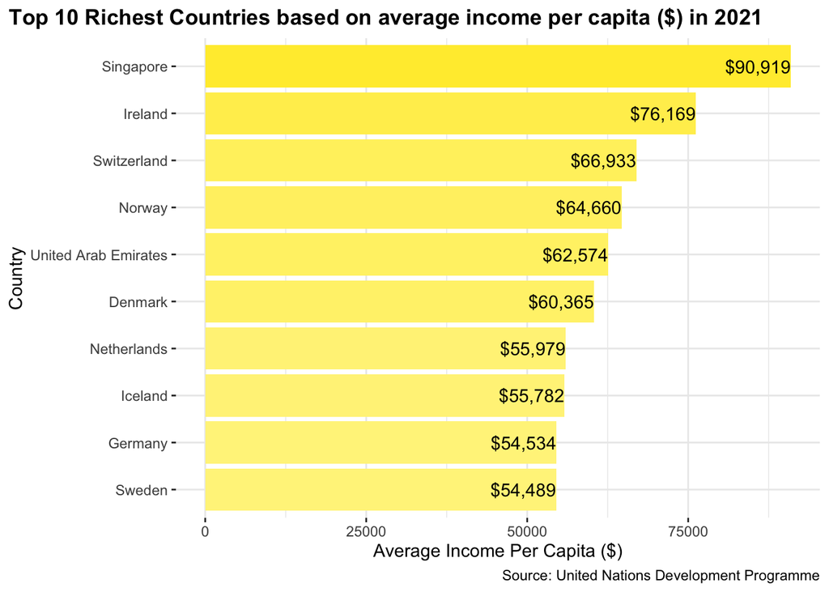

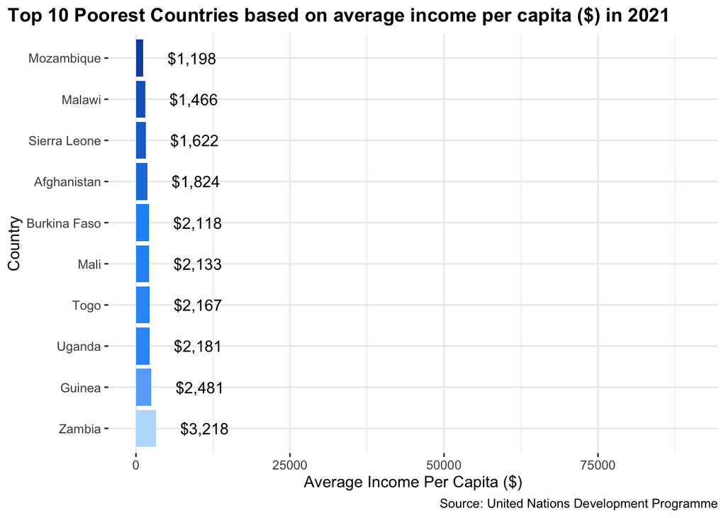

```r
#-------------------------------PLOTTING POOREST COUNTRIES-----------------------
#Arranging data in ascending order and selecting first 10
MostPoor <- Joined_Data %>%
    arrange(Average.Income) %>% #Arrange data in ascending order
    slice(1:10) %>% #Select the first 10 data points
    arrange(desc(Average.Income)) %>% #Arrange in descending order so plotted in right order
    mutate(Country = factor(Country, levels = Country)) #Mutate country column to display correct order

#Plotting top 10 poorest countries
p_poor <- ggplot(MostPoor, aes(x = Country, y = Average.Income)) #Adding mappings to ggplot

p_poor <- p_poor + #Adding geom layer to ggplot
          geom_col(aes(fill=Average.Income)) + #Plotting x and y as bar chart
          coord_flip() + #Making bars horizontal
          scale_fill_gradient2(low = "#0D47A1", high = "#BBDEFB", mid = "#2196F3",
          midpoint = median(MostPoor$Average.Income)) + #Filling bars based on average income
          geom_text(aes(label = dollar(Average.Income)), hjust = -0.5, color = "black") + #Income next to bar
          ylim(0, 90000) + #Setting scale to match top 10 rich countries bar chart
          labs(title = "Top 10 Poorest Countries based on average income per capita ($) in 2021", #Add labels
          x= "Country", y = "Average Income Per Capita ($)",
          caption = "Source: United Nations Development Programme") +
          theme_bw() +  #Setting the plot theme
          theme(text = element_text(family = "Arial"), #Change font
                plot.title = element_text(face = "bold"), #Bold title
                plot.title.position = "plot", #Move title
                panel.border = element_blank(), #Remove background
                legend.position="none") #Remove legend

#Saving the plot
ggsave(here("Figures", "Top 10 Poorest Countries.png"), plot = p_poor)

#The following was included in the rMarkdown code block to plot each graph side by side
#{r, echo=FALSE, figures-side, fig.show="hold", out.width="50%"}
```

**Aim 3 = Which countries are the richest and the poorest based on average national income per capita?**  
The decision was made to make the scale the same for both graphs to show the dramatic difference in average income between the top 10 richest countries and the top 10 poorest countries. This graph again shows that 8 out of the top 10 richest countries are in Europe, whilst 9 out of the top 10 poorest countries are in Africa. This is very similar to the happiness rating graphs and, therefore, further indicates a potential relationship between the two variables. By matching the axis scales on both graphs, this visualisation shows the striking difference in average income between the richest and poorest countries.

## **Visualisation 4: The Relationship Between Average Income and Happiness Score**

The previous visualisations indicate a potential relationship between average income and happiness score. Therefore, the last visualisation includes a scatterplot of the two variables to help identify if there is a relationship between them.

It is important to note that this visualisation only displays countries which had a happiness rating *and* average income data for 2021 and therefore, interpretation of this visualisation can only be used to assess the relationship of the two variables together and not to assess the richest or happiest country alone i.e., there may have been a country with a greater average income, but if there was no happiness rating for 2021, it was not included in this scatterplot.

#### Creating scatterplot of average income against happiness score

```r
#Adding column with continent to display colour coded points on the scatterplot
Joined_Data$continent <- countrycode(sourcevar = Joined_Data$Country, #Select country column to be converted
                                     origin = "country.name", #Identify coding scheme of origin
                                     destination = "continent") #Identify wanted coding scheme

#Creating tooltip column for hover text
Joined_Data <- Joined_Data %>%
                mutate(tooltip_text = paste0(Country, "\n",
                                             "Happiness Score: ", round(Happiness_Score, 3), "\n",
                                              "Average Income: ", dollar(Average.Income)))

#Creating scatterplot - ggiraph package is used to make scatterplot interactive - when mouse hovers over points on the plot, country name, happiness score and average income will be visible
p_both <- ggplot(Joined_Data, aes(Average.Income, Happiness_Score)) + #Apply data as variables to ggplot
          scale_colour_manual(values=c("#FFCC00", "red", "#339000", "black", "#3999FF")) + #Add colours for continent
          geom_point_interactive(aes(col = continent, tooltip = tooltip_text)) + #Make scatterplot with hover text
          #Add logarithmic regression line
          geom_smooth(method="lm", formula= y ~ log(x), se = FALSE, color = "black", size = 0.5) +
          labs(title = "The Relationship Between Average Income and Happiness Score", #Add labels
               subtitle = "Data from 104 countries in 2021",
               x = "Average Net National Income Per Capita, US($)",
               y = "Happiness Score",
               caption = "Source: World Happiness Report, United Nations Development Programme",
               color = "Continent") +
           theme(text = element_text(family = "Arial"), #Change font
                 plot.title = element_text(face = "bold"), #Make title bold
                 plot.title.position = "plot") #Move title position

#Saving the plot
ggsave(here("Figures", "Average Income and Happiness Score.png"), plot = p_both)

#Display interactive graph with girafe() function
girafe(ggobj = p_both)
```

[interactive chart not shown]

**Aim 4 = Is there a relationship between average income and overall happiness?**  
Using the Olympic colours to represent each continent, the scatterplot confirms what was found in the previous visualisations, African countries have the lowest incomes and relatively low happiness scores. In comparison, European countries mainly have higher incomes and higher happiness scores. However, the relationship between the two variables does not appear to be linear and therefore, a logarithmic regression line was used to show the relationship.

## **Summary**

It would seem that money *can* buy happiness but only up to a certain point. The regression line shows a rapid initial increase before beginning to plateau, suggesting that money can make you happy up until a certain point, but after that, increasing your income will have no further effect on happiness. This finding is in support of [Kahneman and Deaton (2010)](https://doi.org/10.1073/pnas.1011492107), who found that well-being levels increased with income up until $75,000 before plateauing. [Killingsworth (2021)](https://www.washingtonpost.com/business/2023/03/08/money-wealth-happiness-study/) state that, for the most part, larger incomes are associated with greater happiness. However, there is an exception for rich people who are unhappy or depressed, where more money simply does not help.

### **Limitations and Future Directions**

It is important to consider other contributing factors to happiness scores, as happiness isn’t entirely dependent on money. The countries with the lowest happiness ratings are mainly third world countries, whilst the highest rated countries are mostly first world countries, and consequently, there are likely to be many other factors contributing to the happiness scores. Other contributing factors may include war, quality of life, access to healthcare etc.

The happiness data set included several variables which contributed to the overall happiness score, but due to the time constraints of this module, only the overall happiness score was visualised. Future visualisations using this data could explore the contributors to the happiness score to see which variables had the biggest impact on well-being.

### **References**

Freeland, Z. (2019). *Can money buy happiness? It sure can.* [Image]. Vox. https://www.vox.com/the-highlight/2019/11/13/20951937/money-experiences-buy-happiness-happy-how-to-spend

Kahneman, D., & Deaton, A. (2010). High income improves evaluation of life but not emotional well-being. *Proceedings of the national academy of sciences, 107*(38), 16489-16493. https://doi.org/10.1073/pnas.1011492107

Suliman, A. (2023, March 8). *Can money buy happiness? Scientists say it can.* The Washington Post. https://www.washingtonpost.com/business/2023/03/08/money-wealth-happiness-study/

The rMarkdown file along with all the files needed to reproduce this analysis can be found on [GitHub](https://github.com/AZiebland/PSY6422)